# Spatial analyses of 2020-21 excess mortality in CH

Grid & grided data preparation

# Grid

## Municipality boundaries

Used to ‘clip’ the data to the country outline, ‘remove’ the area of lakes and introduce the boundaries within grid cells belonging to two different municipalities.

```r
st_gg21 <- read_rds("data/swisstopo/st_gg21.Rds") %>%
  st_transform(2056)

st_se21_sel <- read_rds("data/swisstopo/st_se21_sel.Rds") %>%
  st_transform(2056)
```

## Offset

One of the meteoswiss datasets is used to define `offset` (ie. starting point; lowest left corner) for `st_make_grid`.

Using meteoswiss origin allows us to perfectly align gridded mortality and population data to meteo data.

```r
p_load(ncdf4)

TabsD_14 <- nc_open("data-raw/meteoswiss/TabsM_ch01r.swiss.lv95_201401010000_201412010000.nc")

E <- ncvar_get(TabsD_14, "E") # X, lon
N <- ncvar_get(TabsD_14, "N") # Y, lat

offset_meteoswiss <- as_tibble(cbind(
  minX = as.integer(min(E)),
  minY = as.integer(min(N))
))

p_unload(ncdf4)
```

## Grid creation

Grid is then overlaid with *swisstopo municipality data* to select only cells that overlay it.

At next step the areas of lakes are ‘clipped’ from the grid.

Lastly, grid integrating municipality boundaries is also created.

Also, adding ID for each cell (based on row number) and area for each of the iterations.

```r
grid_1km <- st_gg21 %>%
  st_make_grid(
    cellsize = 1000, square = TRUE,
    offset = c(offset_meteoswiss$minX, offset_meteoswiss$minY)
  ) %>%
  st_sf() %>%
  st_cast("POLYGON") %>%
  st_filter(st_gg21, join = st_covers) %>%
  mutate(ID = row_number()) %>%
  relocate(ID) %>%
  st_transform(2056)

# this one takes some time
grid_1km_crop <- grid_1km %>%
  st_intersection(st_union(st_gg21)) %>%
  st_collection_extract("POLYGON") %>%
  mutate(area = st_area(.)) %>%
  relocate(ID, area) %>%
  st_transform(2056)

grid_1km_over <- grid_1km_crop %>%
  st_intersection(st_gg21) %>%
  mutate(
    ID2 = row_number(),
    area2 = st_area(.)
  ) %>%
  relocate(ID, ID2, area, area2) %>%
  st_transform(2056)
```

## Grid example

[interactive chart not shown]

## Grid comparison

Example of different integration of boundaries of `Gottlieben` municipality.

Comparing grid of ‘regular’ cells (green) and cells ‘cropped’ by outlines of the country and water bodies. Only grid cells that overlay area of municipality are shown (purple):

[interactive chart not shown]

Comparing grid of ‘cropped’ cells (red again) with grid integrating community boundaries (yellow). Note subdivision of regular cells into smaller ([sometimes very small!](https://github.com/RPanczak/ISPM_geo-mortality/issues/49)) units:

[interactive chart not shown]

## Grid centroids

```r
grid_1km_cent <- st_centroid(grid_1km)

grid_1km_cent %<>%
  mutate(
    X = st_coordinates(.)[, 1],
    Y = st_coordinates(.)[, 2]
  ) %>%
  relocate(geometry, .after = last_col())
```

Example of Bern:

[interactive chart not shown]

Of course different grids will result in slightly different centroids in areas that were modified:

[interactive chart not shown]

# Gridded temperature data

Using gridded data from [meteoswiss](https://www.meteoswiss.admin.ch/home/climate/swiss-climate-in-detail/raeumliche-klimaanalysen.html).

Using `TabsM`: *Monthly mean temperature* dataset for the years of interest.

## Monthly data

Example of two months in 2014:

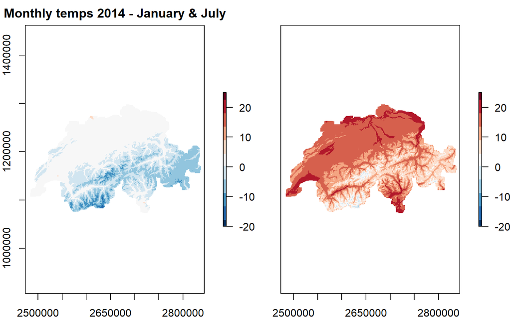

**Note:** *there is known, unsolved issue with projection of meteoswiss’ nc files!*

## Extract

Extract function

```r
extract_temps <- function(filename, year) {

  # r <- raster::stack(filename) # same same
  r <- raster::brick(filename)
  raster::crs(r) <- sf::st_crs(2056)$proj4string

  ex <- raster::extract(r, grid_1km_cent, df = TRUE)
  ex <- tibble::as_tibble(ex)
  repeats <- nrow(ex)

  ex <- pivot_longer(ex,
                     !ID,
                     names_to = "date_temp",
                     values_to = "temperature"
  )

  ex$year <- as.integer(year)
  ex$month <- rep(seq(1, 12), repeats)
  ex$date_temp <- NULL

  return(ex)
}
```

Combining years:

```r
temperature <- bind_rows(
  extract_temps("data-raw/meteoswiss/TabsM_ch01r.swiss.lv95_201401010000_201412010000.nc", 2014),
  extract_temps("data-raw/meteoswiss/TabsM_ch01r.swiss.lv95_201501010000_201512010000.nc", 2015),
  extract_temps("data-raw/meteoswiss/TabsM_ch01r.swiss.lv95_201601010000_201612010000.nc", 2016),
  extract_temps("data-raw/meteoswiss/TabsM_ch01r.swiss.lv95_201701010000_201712010000.nc", 2017),
  extract_temps("data-raw/meteoswiss/TabsM_ch01r.swiss.lv95_201801010000_201812010000.nc", 2018),
  extract_temps("data-raw/meteoswiss/TabsM_ch01r.swiss.lv95_201901010000_201912010000.nc", 2019),
  extract_temps("data-raw/meteoswiss/TabsM_ch01r.swiss.lv95_202001010000_202012010000.nc", 2020),
  extract_temps("data-raw/meteoswiss/TabsM_ch01r.swiss.lv95_202101010000_202112010000.nc", 2021)
) %>%
  filter(!(year == 2021 & month > 6))
```

## Examples of time series

Data for Lugano & Jungfraujoch.

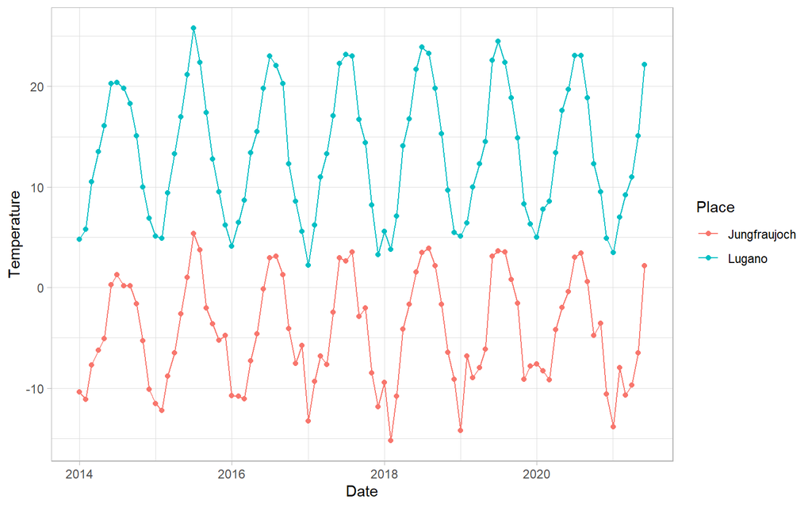

# Gridded deaths 2014-2019

## SNC data

Prepared in `/Stata/mort_2014-2020.do`.

```r
snc5_deaths <- read_dta("data/BfS-closed/SNC/deaths.dta") %>%
  zap_formats() %>%
  zap_labels() %>%
  zap_label() %>%
  dplyr::select(-geoyear, -dob) %>%
  dplyr::rename(year = yod) %>%
  mutate(
    yod = as.integer(year),
    sex = if_else(sex == "1", "Female", "Male"),
    sex = factor(sex),
    age = cut(age_death,
              breaks = c(0, 40, seq(50, 80, 10), 120), right = FALSE,
              labels = c("<40", "40-49", "50-59", "60-69", "70-79", "80+")
    ),
    month = month(dod)
  ) %>%
  relocate(month, .after = year) %>%
  dplyr::select(-age_death, -dod) %>%
  relocate(age, .after = sex) %>%
  st_as_sf(
    coords = c("geox", "geoy"),
    crs = 2056,
    remove = TRUE
  )
```

## Aggregate deaths by grid

```r
temp <- st_join(snc5_deaths,
                grid_1km,
                join = st_intersects
) %>%
  st_drop_geometry() %>%
  group_by(ID, year, month, sex, age) %>%
  summarize(deaths = as.integer(n())) %>%
  ungroup()

st_grid_deaths_2014_2019 <-
  expand_grid(
    ID = unique(grid_1km$ID),
    year = unique(temp$year),
    month = unique(temp$month),
    sex = unique(temp$sex),
    age = unique(temp$age)
  ) %>%
  dplyr::arrange(ID, year, month, sex, age) %>%
  left_join(temp) %>%
  mutate(deaths = replace_na(deaths, 0)) %>%
  mutate(deaths = as.integer(deaths))
```

# Gridded population data 2014-2020

## Function

Defined in `geom_001_pe_to_grid.R`.

```r
source("R/geom_001_pe_to_grid.R")
```

## Sources

STATPOP data, state of 31st Dec each year. Aggregating individual level data to building level, spatial join to grid.

Example of most recent data:

```r
gc()
r20_pe_grid <- geom_001_pe_to_grid("data-raw/BfS-closed/STATPOP/statpop2020_220098p.zip")
write_rds(r20_pe_grid, "data/BfS-closed/STATPOP/r20_pe_grid.Rds")
rm(r20_pe_grid)
gc()
```

Combining together:

```r
pe_grid <- bind_rows(
  read_rds("data/BfS-closed/STATPOP/r20_pe_grid.Rds") %>%
    st_drop_geometry() %>% select(-egid),
  read_rds("data/BfS-closed/STATPOP/r19_pe_grid.Rds") %>%
    st_drop_geometry() %>% select(-egid),
  read_rds("data/BfS-closed/STATPOP/r18_pe_grid.Rds") %>%
    st_drop_geometry() %>% select(-egid),
  read_rds("data/BfS-closed/STATPOP/r17_pe_grid.Rds") %>%
    st_drop_geometry() %>% select(-egid),
  read_rds("data/BfS-closed/STATPOP/r16_pe_grid.Rds") %>%
    st_drop_geometry() %>% select(-egid),
  read_rds("data/BfS-closed/STATPOP/r15_pe_grid.Rds") %>%
    st_drop_geometry() %>% select(-egid),
  read_rds("data/BfS-closed/STATPOP/r14_pe_grid.Rds") %>%
    st_drop_geometry() %>% select(-egid)
)
```

## Aggregate by grid/municipality

```r
lu_grid_gem <- pe_grid %>%
  group_by(year, sex, age, ID, ID2, area, area2, GMDNR, GMDNAME, KTNR, KTNAME) %>%
  summarise(pop = sum(n), .groups = "drop") %>%
  dplyr::arrange(year, ID, ID2, sex, age)
```

## Expand grid for combinations with 0

```r
lu_grid_gem <- grid_1km_over %>%
  sf::st_drop_geometry() %>%
  dplyr::as_tibble() %>%
  dplyr::select(ID, ID2, area, area2, GMDNR, GMDNAME, KTNR, KTNAME) %>%
  tidyr::expand_grid(
    year = unique(lu_grid_gem$year),
    age = unique(lu_grid_gem$age),
    sex = unique(lu_grid_gem$sex)
  ) %>%
  dplyr::arrange(year, ID, ID2, sex, age) %>%
  dplyr::left_join(lu_grid_gem) %>%
  dplyr::mutate(pop = if_else(is.na(pop), as.integer(0), pop)) %>%
  dplyr::mutate(year = as.integer(year))
```

## Aggregate by grid

```r
st_grid_pop <- lu_grid_gem %>%
  dplyr::group_by(ID, year, age, sex) %>%
  dplyr::summarise(pop = sum(pop), .groups = "drop")
```

# Gridded deaths 2020-2021

Redistributing municipality level deaths for 2020-2021 into grid.

Done using `04-02_grid-deaths.R` script on HPC.

# Extrapolated population after 2019

FIXME: check year_month definition!

## Data for modelling

```r
st_grid_pop_exp <- dplyr::bind_rows(
  st_grid_pop %>%
    dplyr::filter(year != 2020),
  st_grid_pop %>%
    dplyr::filter(year >= 2018) %>%
    dplyr::mutate(year = year + 2) %>%
    dplyr::mutate(pop = NA_integer_)
) %>%
  dplyr::arrange(ID, year, age, sex) %>%
  dplyr::mutate(
    # year_month = year + ,
    id_year = year - 2013,
    id_age = as.integer(as.factor(age))
  )
```

## Examples

Zero pops example:

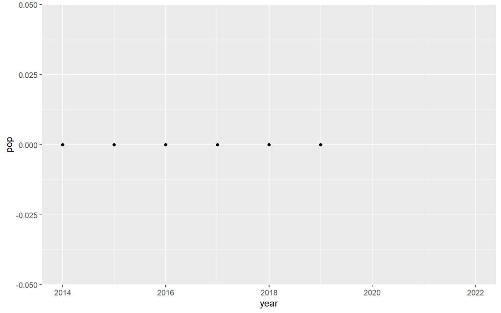

Max pops example:

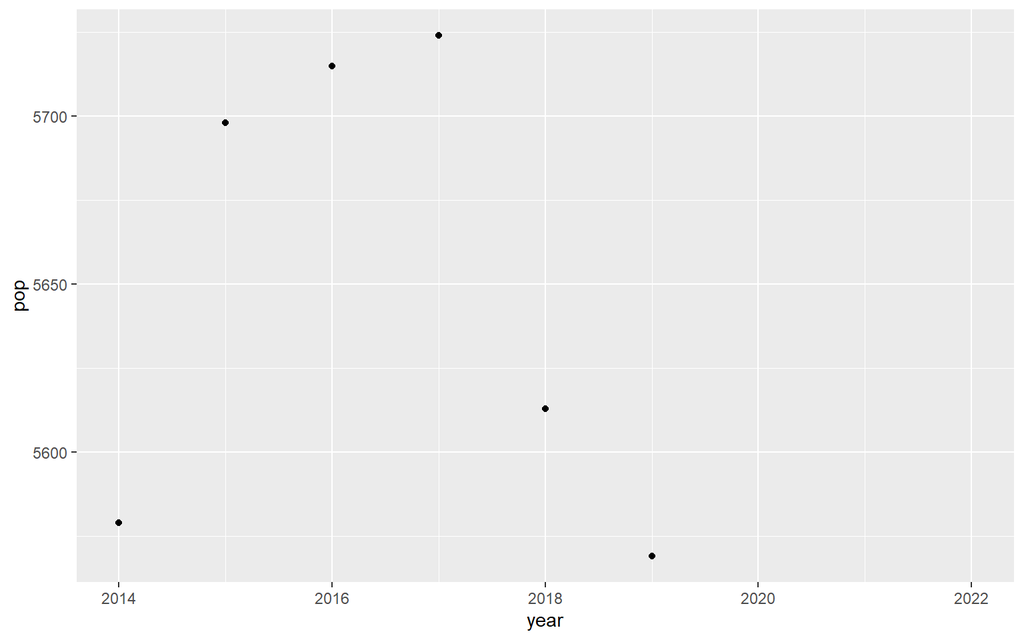

## Zeroes

Frequency:

```
pop == 0 <lgl>
# total N=2994984 valid N=2994984 mean=0.61 sd=0.49

Value |       N | Raw % | Valid % | Cum. %
------------------------------------------
FALSE | 1171102 | 39.10 |   39.10 |  39.10
TRUE  | 1823882 | 60.90 |   60.90 | 100.00
<NA>  |       0 |  0.00 |    <NA> |   <NA>
```

Distribution:

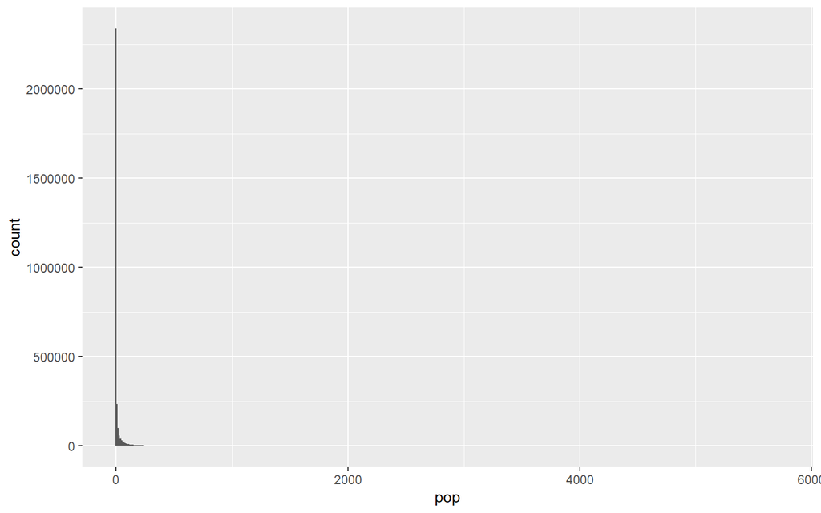

## Processing

Done using `04-03_grid-pops.R` script on HPC.